# Regression Project _ Motor Trend

Luoning

5/15/2020

## 1.Synopsis

The work is based on data of Motor Trend, a magazine about the automobile industry. The data set of a collection of cars was reviewed. And the relationship between a set of variables and miles per gallon (MPG) (outcome) was analyzed. Two particular questions were answered: 1) whether an automatic or manual transmission is better for MPG; 2) whether the the MPG difference between automatic and manual transmissions can be quantified.

## 2.Data download and process

```r
# Datasets
library(datasets)
data(mtcars)

# View of the data
head(mtcars)
```

|  | mpg | cyl | disp | hp | drat | wt | qsec | vs | am | gear | carb |
| --- | --- | --- | --- | --- | --- | --- | --- | --- | --- | --- | --- |
| Mazda RX4 | 21.0 | 6 | 160 | 110 | 3.90 | 2.620 | 16.46 | 0 | 1 | 4 | 4 |
| Mazda RX4 Wag | 21.0 | 6 | 160 | 110 | 3.90 | 2.875 | 17.02 | 0 | 1 | 4 | 4 |
| Datsun 710 | 22.8 | 4 | 108 | 93 | 3.85 | 2.320 | 18.61 | 1 | 1 | 4 | 1 |
| Hornet 4 Drive | 21.4 | 6 | 258 | 110 | 3.08 | 3.215 | 19.44 | 1 | 0 | 3 | 1 |
| Hornet Sportabout | 18.7 | 8 | 360 | 175 | 3.15 | 3.440 | 17.02 | 0 | 0 | 3 | 2 |
| Valiant | 18.1 | 6 | 225 | 105 | 2.76 | 3.460 | 20.22 | 1 | 0 | 3 | 1 |

```r
str(mtcars)
```

```
## 'data.frame':    32 obs. of  11 variables:
##  $ mpg : num  21 21 22.8 21.4 18.7 18.1 14.3 24.4 22.8 19.2 ...
##  $ cyl : num  6 6 4 6 8 6 8 4 4 6 ...
##  $ disp: num  160 160 108 258 360 ...
##  $ hp  : num  110 110 93 110 175 105 245 62 95 123 ...
##  $ drat: num  3.9 3.9 3.85 3.08 3.15 2.76 3.21 3.69 3.92 3.92 ...
##  $ wt  : num  2.62 2.88 2.32 3.21 3.44 ...
##  $ qsec: num  16.5 17 18.6 19.4 17 ...
##  $ vs  : num  0 0 1 1 0 1 0 1 1 1 ...
##  $ am  : num  1 1 1 0 0 0 0 0 0 0 ...
##  $ gear: num  4 4 4 3 3 3 3 4 4 4 ...
##  $ carb: num  4 4 1 1 2 1 4 2 2 4 ...
```

The data frame has 32 observatoins on 11 variables.  
[, 1] mpg Miles/(US) gallon  
[, 2] cyl Number of cylinders  
[, 3] disp Displacement (cu.in.)  
[, 4] hp Gross horsepower  
[, 5] drat Rear axle ratio  
[, 6] wt Weight (1000 lbs)  
[, 7] qsec 1/4 mile time  
[, 8] vs Engine (0 = V-shaped, 1 = straight)  
[, 9] am Transmission (0 = automatic, 1 = manual)  
[,10] gear Number of forward gears  
[,11] carb Number of carburetors

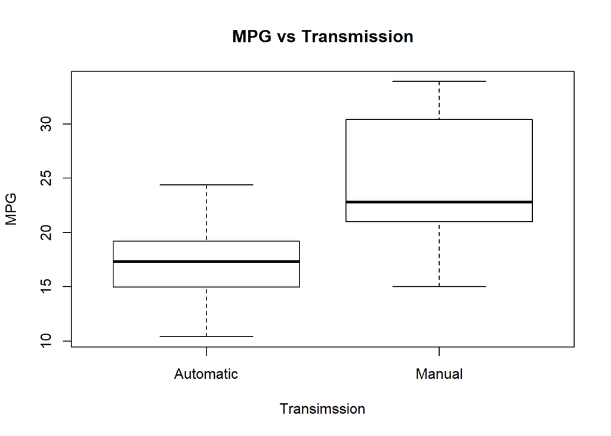

```r
library(dplyr)
mtcars<-mutate(mtcars,Transmission=am)
mtcars$Transmission[mtcars$Transmission==1]<-'Manual'
mtcars$Transmission[mtcars$Transmission==0]<-'Automatic'
mtcars$Transmission<-factor(paste(mtcars$Transmission))
# Plot the mpg of manual vs automatic
boxplot(mtcars$mpg ~ mtcars$Transmission, data=mtcars, outpch = 19, ylab="MPG", xlab="Transimssion", main="MPG vs Transmission")
```

From visuallization, the mpg of manual transmission is higher than that of automatic transmission. Now let’s evaluate the significance.

```r
auto<-mtcars[mtcars$Transmission=='Automatic',]
manual<-mtcars[mtcars$Transmission=='Manual',]
t.test(auto$mpg,manual$mpg)
```

```
##
##  Welch Two Sample t-test
##
## data:  auto$mpg and manual$mpg
## t = -3.7671, df = 18.332, p-value = 0.001374
## alternative hypothesis: true difference in means is not equal to 0
## 95 percent confidence interval:
##  -11.280194  -3.209684
## sample estimates:
## mean of x mean of y
##  17.14737  24.39231
```

The t value is negative and the confidence interval is absolutely below zero, which means the hypothesis that the automatic and manual transmission are the same (t=0) is rejected. The difference in the mpg of automatic and manual transmission is significant, and the mpg of automatic is lower than manual.

## Regression Model

To quantify the difference between the automatic and manual transmission. The regression model is applied to evaluate the correlation of all other variables vs. transmission and mpg relationship.

```r
fit1<-lm(mpg~am,mtcars)
summary(fit1)
```

```
##
## Call:
## lm(formula = mpg ~ am, data = mtcars)
##
## Residuals:
##     Min      1Q  Median      3Q     Max
## -9.3923 -3.0923 -0.2974  3.2439  9.5077
##
## Coefficients:
##             Estimate Std. Error t value Pr(>|t|)
## (Intercept)   17.147      1.125  15.247 1.13e-15 ***
## am             7.245      1.764   4.106 0.000285 ***
## ---
## Signif. codes:  0 '***' 0.001 '**' 0.01 '*' 0.05 '.' 0.1 ' ' 1
##
## Residual standard error: 4.902 on 30 degrees of freedom
## Multiple R-squared:  0.3598, Adjusted R-squared:  0.3385
## F-statistic: 16.86 on 1 and 30 DF,  p-value: 0.000285
```

The p-value is low but the R value is only 0.3385, which means other variables may influence the mpg. Now let’s consider other variables and perform the multivariable linear regression.

```r
fit2<-lm(mpg~am+cyl,mtcars)
anova(fit1,fit2)
```

|  | Res.Df | RSS | Df | Sum of Sq | F | Pr(>F) |
| --- | --- | --- | --- | --- | --- | --- |
| 1 | 30 | 720.8966 | NA | NA | NA | NA |
| 2 | 29 | 271.3621 | 1 | 449.5345 | 48.04097 | 1.28456e-07 |

The p-value is low and the cyl is significant, which means the addition of cyl as a variable is necessary. We can add more variables to check the significance.

```r
fit2.1<-lm(mpg~am+cyl+disp+hp+drat,mtcars)
anova(fit2,fit2.1)
```

|  | Res.Df | RSS | Df | Sum of Sq | F | Pr(>F) |
| --- | --- | --- | --- | --- | --- | --- |
| 1 | 29 | 271.3621 | NA | NA | NA | NA |
| 2 | 26 | 214.4969 | 3 | 56.86522 | 2.297618 | 0.1010487 |

The addition of displacement (disp), Gross horsepower (hp) and Rear axle ratio (drat) is not necessary.

```r
fit2.2<-lm(mpg~am+cyl+wt+qsec+vs,mtcars)
anova(fit2,fit2.2)
```

|  | Res.Df | RSS | Df | Sum of Sq | F | Pr(>F) |
| --- | --- | --- | --- | --- | --- | --- |
| 1 | 29 | 271.3621 | NA | NA | NA | NA |
| 2 | 26 | 167.5171 | 3 | 103.845 | 5.372529 | 0.005162962 |

```r
fit2.3<-lm(mpg~am+cyl+gear+carb,mtcars)
anova(fit2,fit2.3)
```

|  | Res.Df | RSS | Df | Sum of Sq | F | Pr(>F) |
| --- | --- | --- | --- | --- | --- | --- |
| 1 | 29 | 271.3621 | NA | NA | NA | NA |
| 2 | 27 | 206.5799 | 2 | 64.7822 | 4.233518 | 0.02516372 |

The new variables weight (wt), 1/4 mile time (qsec) and Engine (vs) has at least one variable necessary. And at least one in number of forward gears (gear) and number of carburetors (carb) is necessary.

```r
fit2.4<-lm(mpg~am+cyl+wt,mtcars)
fit2.5<-lm(mpg~am+cyl+wt+qsec,mtcars)
fit2.6<-lm(mpg~am+cyl+wt+qsec+vs,mtcars)
anova(fit2,fit2.4,fit2.5,fit2.6)
```

|  | Res.Df | RSS | Df | Sum of Sq | F | Pr(>F) |
| --- | --- | --- | --- | --- | --- | --- |
| 1 | 29 | 271.3621 | NA | NA | NA | NA |
| 2 | 28 | 191.0471 | 1 | 80.3150598 | 12.46554434 | 0.00156899 |
| 3 | 27 | 167.7849 | 1 | 23.2621887 | 3.61047910 | 0.06856054 |
| 4 | 26 | 167.5171 | 1 | 0.2677946 | 0.04156387 | 0.84004072 |

```r
fit3<-lm(mpg~am+cyl+wt,mtcars)
fit3.1<-lm(mpg~am+cyl+wt+gear,mtcars)
fit3.2<-lm(mpg~am+cyl+wt+gear+carb,mtcars)
anova(fit3,fit3.1,fit3.2)
```

|  | Res.Df | RSS | Df | Sum of Sq | F | Pr(>F) |
| --- | --- | --- | --- | --- | --- | --- |
| 1 | 28 | 191.0471 | NA | NA | NA | NA |
| 2 | 27 | 183.9315 | 1 | 7.11558 | 1.099436 | 0.3040395 |
| 3 | 26 | 168.2727 | 1 | 15.65879 | 2.419458 | 0.1319262 |

```r
summary(fit3)
```

```
##
## Call:
## lm(formula = mpg ~ am + cyl + wt, data = mtcars)
##
## Residuals:
##     Min      1Q  Median      3Q     Max
## -4.1735 -1.5340 -0.5386  1.5864  6.0812
##
## Coefficients:
##             Estimate Std. Error t value Pr(>|t|)
## (Intercept)  39.4179     2.6415  14.923 7.42e-15 ***
## am            0.1765     1.3045   0.135  0.89334
## cyl          -1.5102     0.4223  -3.576  0.00129 **
## wt           -3.1251     0.9109  -3.431  0.00189 **
## ---
## Signif. codes:  0 '***' 0.001 '**' 0.01 '*' 0.05 '.' 0.1 ' ' 1
##
## Residual standard error: 2.612 on 28 degrees of freedom
## Multiple R-squared:  0.8303, Adjusted R-squared:  0.8122
## F-statistic: 45.68 on 3 and 28 DF,  p-value: 6.51e-11
```

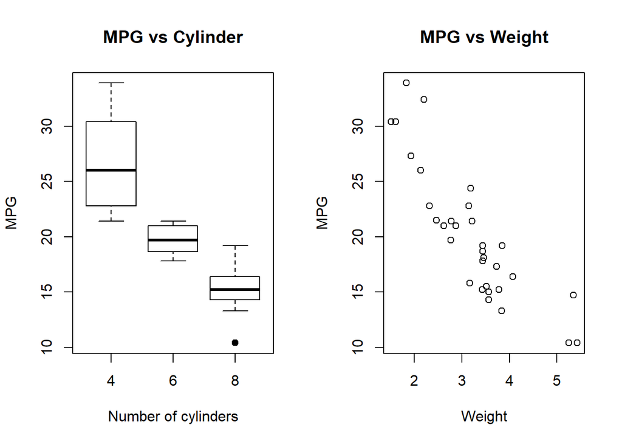

```r
par(mfrow=c(1,2))
boxplot(mtcars$mpg ~ mtcars$cyl, data=mtcars, outpch = 19, ylab="MPG", xlab="Number of cylinders", main="MPG vs Cylinder")
plot(mtcars$mpg ~ mtcars$wt, data=mtcars, outpch = 19, ylab="MPG", xlab="Weight", main="MPG vs Weight")
```

## Residual and Diagnostics

Multivariable regression model residuals

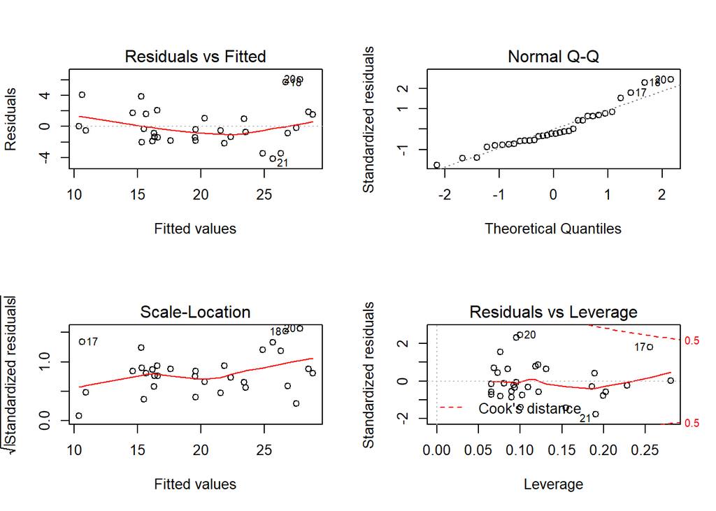

```r
par(mfrow=c(2,2))
plot(fit3)
```

```r
par(mfrow=c(1,1))
```

From the above plots, we can make the following observations:  
The residuals appear to be randomly scattered on the plot and verify the independence condition.  
The points in Q-Q plot mostly fall on the line which indicates the normally distributed residuals.  
The Scale-Location plot consists of points scattered in a constant band pattern, indicating constant variance.  
The outliers or leverage points are limited and acceptible.